# 1- Explore the data and suggest a solution to guide the drivers towards areas with higher expected demand at given time and location

```python
#finding unique areas and the timestamp of the order
#start_unique_timestamps= data.groupby(['start_lat','start_lng'])['Time_Bin'].unique().reset_index().rename(columns={0:'count'})

#start_unique_timestamps
```

```python
# Combining (areas by order count) and (areas by order price)

df_count_price = pd.merge(start_unique_area_order_count, start_unique_area_order_price,  how='inner',
                          left_on=['start_lat','start_lng'], right_on = ['start_lat','start_lng'])


df_count_price
```

|  | start_lat | start_lng | count | ride_value |
| --- | --- | --- | --- | --- |
| 0 | 59.322922 | 24.697566 | 1 | 3.327750 |
| 1 | 59.328477 | 24.563372 | 1 | 3.930500 |
| 2 | 59.328495 | 24.563383 | 1 | 3.931609 |
| 3 | 59.328586 | 24.563259 | 1 | 3.821750 |
| 4 | 59.328831 | 24.768888 | 1 | 3.160750 |
| ... | ... | ... | ... | ... |
| 201548 | 59.558653 | 24.807369 | 3 | 10.283250 |
| 201549 | 59.562549 | 24.804545 | 2 | 8.526500 |
| 201550 | 59.565408 | 24.796517 | 1 | 3.895250 |
| 201551 | 59.566246 | 24.796271 | 1 | 3.405250 |
| 201552 | 59.566677 | 24.795947 | 1 | 2.742250 |

201553 rows × 4 columns

```python
#merge df_count_price with "start_unique_timestamps" to create a base table(df_count_price_time)

df_count_price_time = pd.merge(df_count_price, data,  how='inner',
                              left_on=['start_lat','start_lng'], right_on = ['start_lat','start_lng'])

df_count_price_time.drop(['ride_value_y','start_time'], axis = 1, inplace = True)

df_count_price_time = df_count_price_time.rename(columns={'ride_value_x': 'ride_value'})

df_count_price_time
```

|  | start_lat | start_lng | count | ride_value | end_lat | end_lng | Dates | Time | Time_Bin |
| --- | --- | --- | --- | --- | --- | --- | --- | --- | --- |
| 0 | 59.322922 | 24.697566 | 1 | 3.327750 | 59.442809 | 24.691383 | 2022-03-28 | 20:01:08.862207 | Night |
| 1 | 59.328477 | 24.563372 | 1 | 3.930500 | 59.446802 | 24.719087 | 2022-03-05 | 13:34:08.673127 | Afternoon |
| 2 | 59.328495 | 24.563383 | 1 | 3.931609 | 59.446781 | 24.719065 | 2022-03-19 | 13:34:09.886000 | Afternoon |
| 3 | 59.328586 | 24.563259 | 1 | 3.821750 | 59.432512 | 24.744000 | 2022-03-16 | 13:33:46.841180 | Afternoon |
| 4 | 59.328831 | 24.768888 | 1 | 3.160750 | 59.440882 | 24.809819 | 2022-03-01 | 22:50:39.537965 | Night |
| ... | ... | ... | ... | ... | ... | ... | ... | ... | ... |
| 270912 | 59.562549 | 24.804545 | 2 | 8.526500 | 59.413453 | 24.730414 | 2022-03-12 | 20:08:15.127143 | Night |
| 270913 | 59.562549 | 24.804545 | 2 | 8.526500 | 59.413453 | 24.730414 | 2022-03-26 | 20:08:15.127143 | Night |
| 270914 | 59.565408 | 24.796517 | 1 | 3.895250 | 59.427866 | 24.740442 | 2022-03-14 | 21:29:08.409254 | Night |
| 270915 | 59.566246 | 24.796271 | 1 | 3.405250 | 59.451880 | 24.707294 | 2022-03-01 | 02:55:56.437261 | Midnight |
| 270916 | 59.566677 | 24.795947 | 1 | 2.742250 | 59.470338 | 24.840013 | 2022-03-06 | 14:47:16.118351 | Afternoon |

270917 rows × 9 columns

```python
#sorted the base table W.R.T count & ride_value

df_count_price_time_sort = df_count_price_time.sort_values(['count', 'ride_value'], ascending=False)
df_count_price_time_sort
```

|  | start_lat | start_lng | count | ride_value | end_lat | end_lng | Dates | Time | Time_Bin |
| --- | --- | --- | --- | --- | --- | --- | --- | --- | --- |
| 6352 | 59.377896 | 24.685995 | 8 | 12.018000 | 59.426244 | 24.734714 | 2022-03-03 | 20:08:40.890353 | Night |
| 6353 | 59.377896 | 24.685995 | 8 | 12.018000 | 59.426244 | 24.734714 | 2022-03-09 | 20:08:40.890353 | Night |
| 6354 | 59.377896 | 24.685995 | 8 | 12.018000 | 59.426244 | 24.734714 | 2022-03-10 | 20:08:40.890353 | Night |
| 6355 | 59.377896 | 24.685995 | 8 | 12.018000 | 59.426244 | 24.734714 | 2022-03-17 | 20:08:40.890353 | Night |
| 6356 | 59.377896 | 24.685995 | 8 | 12.018000 | 59.426244 | 24.734714 | 2022-03-19 | 20:08:40.890353 | Night |
| ... | ... | ... | ... | ... | ... | ... | ... | ... | ... |
| 185063 | 59.437308 | 24.753295 | 1 | 0.113637 | 59.434943 | 24.753752 | 2022-03-20 | 00:12:40.620000 | Midnight |
| 195448 | 59.438204 | 24.744100 | 1 | 0.113509 | 59.439603 | 24.745684 | 2022-03-28 | 00:45:31.693000 | Midnight |
| 165833 | 59.435341 | 24.725690 | 1 | 0.113168 | 59.436193 | 24.730163 | 2022-03-20 | 23:06:57.312000 | Night |
| 173713 | 59.436294 | 24.751308 | 1 | 0.110604 | 59.438125 | 24.756702 | 2022-03-28 | 02:38:55.886000 | Midnight |
| 176924 | 59.436618 | 24.751602 | 1 | 0.110151 | 59.438991 | 24.757803 | 2022-03-26 | 23:22:43.034000 | Night |

270917 rows × 9 columns

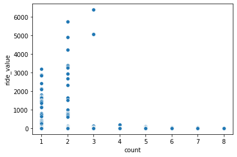

```python
sns.scatterplot(x="count", y="ride_value", data=df_count_price_time_sort)
```

```python
df_count_price_time_sort_2_6 = df_count_price_time_sort.loc[(df_count_price_time_sort['count'] >= 2) &
              (df_count_price_time_sort['count'] <= 6)]
```

```python
df_count_price_time_sort_2_6
```

|  | start_lat | start_lng | count | ride_value | end_lat | end_lng | Dates | Time | Time_Bin |
| --- | --- | --- | --- | --- | --- | --- | --- | --- | --- |
| 231667 | 59.443390 | 24.844295 | 6 | 25.005000 | 59.432053 | 24.544779 | 2022-03-04 | 06:33:42.412632 | Morning |
| 231668 | 59.443390 | 24.844295 | 6 | 25.005000 | 59.432053 | 24.544779 | 2022-03-05 | 06:33:42.412632 | Morning |
| 231669 | 59.443390 | 24.844295 | 6 | 25.005000 | 59.432053 | 24.544779 | 2022-03-05 | 06:33:42.412632 | Morning |
| 231670 | 59.443390 | 24.844295 | 6 | 25.005000 | 59.432053 | 24.544779 | 2022-03-09 | 06:33:42.412632 | Morning |
| 231671 | 59.443390 | 24.844295 | 6 | 25.005000 | 59.432053 | 24.544779 | 2022-03-13 | 06:33:42.412632 | Morning |
| ... | ... | ... | ... | ... | ... | ... | ... | ... | ... |
| 119414 | 59.429654 | 24.755675 | 2 | 0.237889 | 59.426724 | 24.759514 | 2022-03-26 | 22:50:17.512000 | Night |
| 167413 | 59.435484 | 24.749156 | 2 | 0.234997 | 59.435390 | 24.746619 | 2022-03-05 | 22:41:46.142000 | Night |
| 167414 | 59.435484 | 24.749156 | 2 | 0.234997 | 59.435390 | 24.746619 | 2022-03-05 | 22:41:46.142000 | Night |
| 200328 | 59.438638 | 24.757103 | 2 | 0.230888 | 59.438504 | 24.756406 | 2022-03-19 | 22:18:20.108000 | Night |
| 200329 | 59.438638 | 24.757103 | 2 | 0.230888 | 59.438504 | 24.756406 | 2022-03-26 | 22:18:20.108000 | Night |

121144 rows × 9 columns

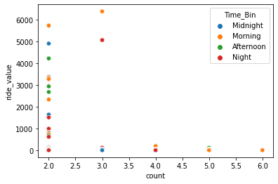

```python
sns.scatterplot(data=df_count_price_time_sort_2_6, x="count", y="ride_value",hue="Time_Bin")
plt.show()
```

# Question 2

Build and document a baseline model for your solution

```python
df_Q2_Morning = data[data['Time_Bin'] == 'Morning']
df_Q2_Afternoon = data[data['Time_Bin'] == 'Afternoon']
df_Q2_Night = data[data['Time_Bin'] == 'Night']
df_Q2_Midnight = data[data['Time_Bin'] == 'Midnight']
```

# 2- Build and document a baseline model for your solution

### For Modeling:

For each of the bins (for each day time created), I am running iterations of the values and then plotting them one-by-one. Comments added with each line.

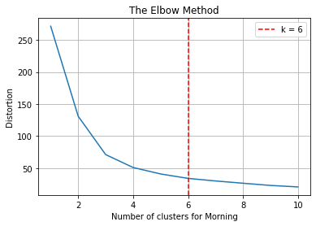

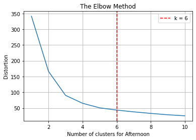

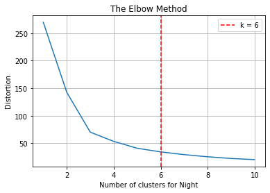

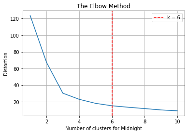

```python
# Model for Morning

X = df_Q2_Morning[["start_lat","start_lng"]]
max_k = 10

## iterations
distortions = []
for i in range(1, max_k+1):
    if len(X) >= i:
       model = cluster.KMeans(n_clusters=i, init='k-means++', max_iter=300, n_init=10, random_state=0)
       model.fit(X)
       distortions.append(model.inertia_)

## best k: the lowest derivative
k = [i*100 for i in np.diff(distortions,2)].index(min([i*100 for i
     in np.diff(distortions,2)]))

## plot
fig, ax = plt.subplots()
ax.plot(range(1, len(distortions)+1), distortions)
ax.axvline(k, ls='--', color="red", label="k = "+str(k))
ax.set(title='The Elbow Method', xlabel='Number of clusters for Morning',
       ylabel="Distortion")
ax.legend()
ax.grid(True)
plt.show()


# Model for Afternoon

X = df_Q2_Afternoon[["start_lat","start_lng"]]
max_k = 10

## iterations
distortions = []
for i in range(1, max_k+1):
    if len(X) >= i:
       model = cluster.KMeans(n_clusters=i, init='k-means++', max_iter=300, n_init=10, random_state=0)
       model.fit(X)
       distortions.append(model.inertia_)

## best k: the lowest derivative
k = [i*100 for i in np.diff(distortions,2)].index(min([i*100 for i
     in np.diff(distortions,2)]))

## plot
fig, ax = plt.subplots()
ax.plot(range(1, len(distortions)+1), distortions)
ax.axvline(k, ls='--', color="red", label="k = "+str(k))
ax.set(title='The Elbow Method', xlabel='Number of clusters for Afternoon',
       ylabel="Distortion")
ax.legend()
ax.grid(True)
plt.show()



# Model for Night

X = df_Q2_Night[["start_lat","start_lng"]]
max_k = 10

## iterations
distortions = []
for i in range(1, max_k+1):
    if len(X) >= i:
       model = cluster.KMeans(n_clusters=i, init='k-means++', max_iter=300, n_init=10, random_state=0)
       model.fit(X)
       distortions.append(model.inertia_)

## best k: the lowest derivative
k = [i*100 for i in np.diff(distortions,2)].index(min([i*100 for i
     in np.diff(distortions,2)]))

## plot
fig, ax = plt.subplots()
ax.plot(range(1, len(distortions)+1), distortions)
ax.axvline(k, ls='--', color="red", label="k = "+str(k))
ax.set(title='The Elbow Method', xlabel='Number of clusters for Night',
       ylabel="Distortion")
ax.legend()
ax.grid(True)
plt.show()


# Model for Night

X = df_Q2_Midnight[["start_lat","start_lng"]]
max_k = 10

## iterations
distortions = []
for i in range(1, max_k+1):
    if len(X) >= i:
       model = cluster.KMeans(n_clusters=i, init='k-means++', max_iter=300, n_init=10, random_state=0)
       model.fit(X)
       distortions.append(model.inertia_)

## best k: the lowest derivative
k = [i*100 for i in np.diff(distortions,2)].index(min([i*100 for i
     in np.diff(distortions,2)]))

## plot
fig, ax = plt.subplots()
ax.plot(range(1, len(distortions)+1), distortions)
ax.axvline(k, ls='--', color="red", label="k = "+str(k))
ax.set(title='The Elbow Method', xlabel='Number of clusters for Midnight',
       ylabel="Distortion")
ax.legend()
ax.grid(True)
plt.show()
```

### Model Visualizations

```python
def Modeling_and_visualizations(df, k, df_count):
##### MODEL FOR MORNING #####

    k = k
    model = cluster.KMeans(n_clusters=k, init='k-means++')
    X = df[["start_lat","start_lng"]]


    ## clustering
    data_X = X.copy()
    data_X["cluster"] = model.fit_predict(X)

    ## find real centroids
    closest, distances = scipy.cluster.vq.vq(model.cluster_centers_,
                        data_X.drop("cluster", axis=1).values)
    data_X["centroids"] = 0
    for i in closest:
        data_X["centroids"].iloc[i] = 1

    ## add clustering info to the original dataset
    df[["cluster","centroids"]] = data_X[["cluster","centroids"]]



    #### plotting for Morning ####
    ## plot
    fig, ax = plt.subplots()
    sns.scatterplot(x="start_lat", y="start_lng", data=df,
                    palette=sns.color_palette("bright",k),
                    hue='cluster', size="centroids", size_order=[1,0],
                    legend="brief", ax=ax)
    th_centroids = model.cluster_centers_
    scatter_plot = ax.scatter(th_centroids[:,0], th_centroids[:,1], s=50, c='black',
              marker="x")



    #### Merging with main dataset #####
    df = pd.merge(df, df_count, how='inner',
                              left_on=['start_lat','start_lng'], right_on = ['start_lat','start_lng'])


    #print(df_Q2_Morning.head(100))



    #### Group by based on ride values and plot
    Morning_cluster_groupby_pricevalue= df.groupby(['cluster'])['ride_value'].sum().reset_index().rename(columns={0:'count'})
    #viz1.Morning_cluster_groupby_pricevalue.plot.bar()

    Morning_cluster_groupby_ridecount= df.groupby(['cluster'])['count'].sum().reset_index().rename(columns={0:'count'})
    #viz2= Morning_cluster_groupby_ridecount.plot.bar()

    return Morning_cluster_groupby_pricevalue.plot.bar(), Morning_cluster_groupby_ridecount.plot.bar(), scatter_plot, df
```

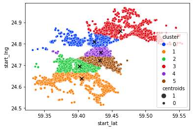

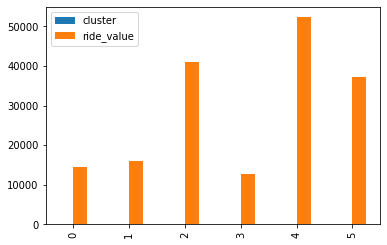

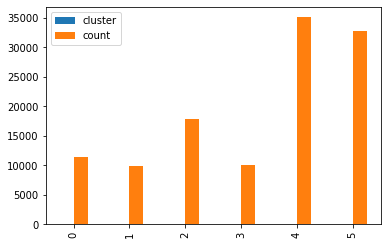

```python
##### MODEL FOR  Morning #####
viz1_Morning, viz2_Morning, scatter_plot_Morning, df_Morning =
Modeling_and_visualizations(df_Q2_Morning, 6 , start_unique_area_order_count)
```

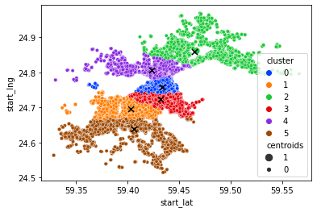

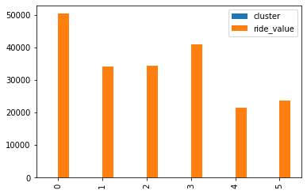

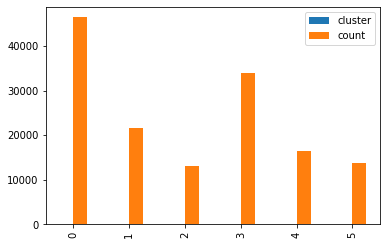

```python
##### MODEL FOR  AFTERNOON #####
viz1_Afternoon, viz2_Afternoon, scatter_plot_Afternoon, df_Afternoon = Modeling_and_visualizations(df_Q2_Afternoon, 6 , start_unique_area_order_count)
```

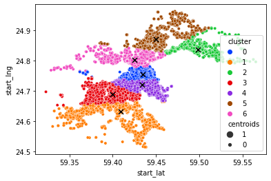

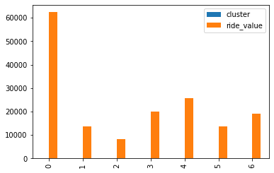

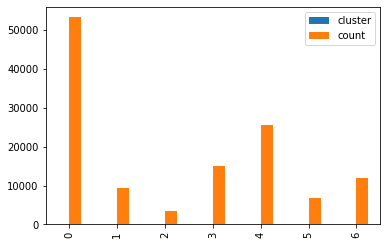

```python
##### MODEL FOR  NIGHT #####
viz1_Night, viz2_Night, scatter_plot_Night, df_Night  = Modeling_and_visualizations(df_Q2_Night, 7 , start_unique_area_order_count)
```

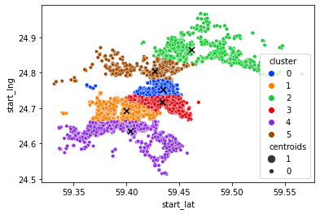

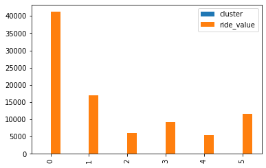

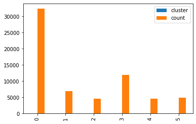

```python
##### MODEL FOR  MID-NIGHT #####
viz1_Midnight, viz2_Midnight, scatter_plot_Midnight, df_Midnight  = Modeling_and_visualizations(df_Q2_Midnight, 6 , start_unique_area_order_count)
```

# 3- Describe how you would design and deploy such a model

### Designing:

I think designing a ML model and the related system is an iterative process.Before setting up the data pipeline or doing data wrangling / basic EDA(Exploratory Data Analysis) it is important to consider the kind of data available and it’s source.

For the given problem statement I think, the data given by bolt was sufficient so this is why I did not use any external data set. For instance, my special consideration went for the data type of time-stamp. The data of 24hours was given in order to simplify it, I broke it down into 4 bins namely (morning, afternoon, night and midnight)

For storage, data can be saved on the cloud if needed (depends on the amount) or in-house bolt’s data centre.

Apart from the given data, if the user’s data holds any privacy concerns then that needs to be anonymized. System should be secure enough theft of against driver or rider’s data or the main ip. Choosing the right authentication tool can be a challenge as there exist ML services which can specifically make model to do some mistakes.

User experience matters too. The app user can be shown the recommendations the entire times they’re using the application. When the GPS is off, it shouldn’t send notifs to not interfere with other activities of the driver.

Performance constraints and sacalibility I believe are core components in ML system design. As the demand will grow, the application will become resource intensive. Needs to make the best out of the server capacity. When the clients make (drivers) make parallel requests to the server. My model should have access to a lot of CPU cores to serve the model.

I can also create a a repository for model registry. This can version, and record specific details of the ML cycle. This will thereby reduce the overhead to manage models.

Bolt’s business require real-time data to be modelled and make quick suggestions. Performance of Model visibility is important, so that we as a Data Scientist know when to retrain the models if the data drifts.

The system should have the capacity to link with the tools like Grafana Loki or DataDog to retrieve analyze real-time predictions. (Monitoring of ML services is extremely important)

Our solution has time-series data which means if new features are added it may offer some kind of latency. To avoid that, can incorporate features store which will act as a common interface for training pipelines and online servings.

### Deployment

Real-Time products needs to cater for the minimum chance of failure. At any such point the model and system should go back to the initial state and automatically reproduce the entire modeling output stack if required.

I will include Continuous integration a part of it to catch the problematice issues before they hit the production. Can do so by testing the main pipeline with automated test to check against business loigics and to validate that data or the prediction metrics are within acceptable bounds.

Once we have the model we will extract it using pickle module. Since the bolt apps are used on phones, we can use java for android version and swift for iOs. Android studio java can be used along with front-end. In the middle of it we can keep a FLASK API containing our ML model which will be rendering JSON output.

When our API is hit, we can parse the output and link it to the front end of our app. Using the GPS live location, the driver’s current location can be picked up and sent to our model.

# 4- Describe how to communicate model recommendations to drivers

Assume driver XYZ opens up the bolt app, our model will fetch his current location. Our recommendation model will suggest him the clusters with higher order numbers closest to him. Then he can decide which cluster to go to. Eg: Cluster 2. Then our model will recommend him the specific geo-location having more orders for that specific cluster 2. Generic steps can be:

- 1- Will redirect the drivers towards the clusters with higher customer / ride count because according to the visualizations made by my model. Higher ride count means higher revenue or the ride value generated.
- 2- Spatial positions of the driver can be picked by the app (my ml model) Neat geo-location tech. Suggest the strategies to the drivers with (day time) and the areas.
- 3- I am assigning priority to each ride request based on the spatial closeness of the driver’s location. Optimizing it with a notification pop-up to suggest the drivers to move into the clusters with higher ride count.

# 5- Think through and describe the design of the experiment that would validate your solution for live operations taking into account marketplace specifics.

Hypothesis: From a product thinking point of view, I choose ride_price as a evaluation metric. I tested that clusters having higher order count in specific time of the day has the higher ride value(amount of money generated)

Validation

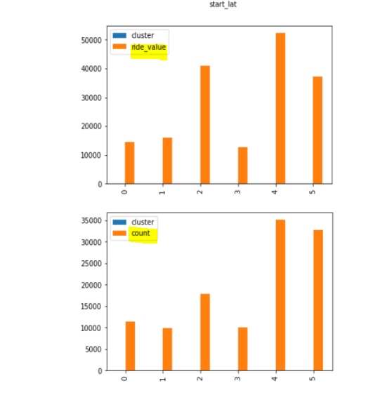

The above figure shows that in Morning, cluster with the highest ride count is 4 . Similarly ride value of cluster 4 is highest. This validates that cluster having the highest ride count also generates the highest revenue for drivers. Ps: I have drawn these graphs in the cells above too for simplicity.

Furthermore, same patterns can be seen in other time of the day eg: Afternoon, Midnight etc.

# The End

## Thank You for Reviewing it